# Dungeons and Dragons: monsters

Sebestyén V.Nagy

# My goal

In this task I would like to build a supervised learning algorithm which helps adventurers in D&D to determine a monsters cr based on the stats it has. So the adventuring party can prepare accordingly.

```r
options(repos = c(CRAN = "https://cran.rstudio.com/"))
install.packages("tidyr")
install.packages("Rsampling")
library(Rsampling)
install.packages("recipes")
library(recipes)
install.packages("parsnip")
library(parsnip)
install.packages("tune")
library(tune)
install.packages("yardstick")
library(yardstick)
library(tidyr)
library(tidyverse)
library(dplyr)
library(psych)
install.packages("tidymodels")
library(tidymodels)
library(car)
library(lmtest)
```

```r
library(ggplot2)
```

# Reading the data in

```r
DandData <- readr::read_csv("https://raw.githubusercontent.com/rfordatascience/tidytuesday/refs/heads/main/data/2025/2025-05-27/monsters.csv")
view(DandData)
describe(DandData)
```

```
##                   vars   n   mean     sd median trimmed    mad min max range
## name*                1 330 165.50  95.41  165.5  165.50 122.31   1 330   329
## category*            2 330  63.92  58.97   50.5   58.76  70.42   1 178   177
## cr                   3 330   4.55   5.80    2.0    3.35   2.78   0  30    30
## size*                4 330   3.81   1.48    4.0    3.72   1.48   1   7     6
## type*                5 330   6.64   4.24    6.0    6.23   5.93   1  16    15
## descriptive_tags*    6  91   6.54   3.81    6.0    6.48   5.93   1  13    12
## alignment*           7 330   6.74   3.29    7.0    7.05   4.45   1  10     9
## ac                   8 330  14.29   3.15   14.0   14.18   2.97   5  25    20
## initiative           9 330   3.15   3.94    2.0    2.50   1.48  -5  20    25
## hp*                 10 330  90.01  55.11   92.5   89.99  70.42   1 183   182
## hp_number           11 330  86.67 102.14   52.0   67.28  57.82   1 697   696
## speed*              12 330  46.69  24.62   44.5   46.28  24.46   1  96    95
## speed_base_number   13 330  30.88  12.34   30.0   31.23  14.83   5  60    55
## str                 14 330  15.38   6.52   16.0   15.50   5.19   1  30    29
## dex                 15 330  12.83   3.26   13.0   12.87   2.97   1  28    27
## con                 16 330  15.18   4.40   14.5   14.76   3.71   8  30    22
## int                 17 330   7.86   5.68    7.0    7.41   7.41   1  25    24
## wis                 18 330  11.82   2.97   12.0   11.74   2.97   3  25    22
## cha                 19 330   9.92   5.97    8.0    9.42   5.93   1  30    29
## str_save            20 330   2.68   3.53    3.0    2.67   2.97  -5  17    22
## dex_save            21 330   2.12   2.45    2.0    1.95   1.48  -5  10    15
## con_save            22 330   2.78   2.87    2.0    2.38   2.22  -1  15    16
## int_save            23 330  -1.09   3.22   -2.0   -1.41   2.97  -5  12    17
## wis_save            24 330   1.87   2.97    1.0    1.48   1.48  -4  12    16
## cha_save            25 330   0.00   3.52   -1.0   -0.38   2.97  -5  12    17
## skills*             26 216  75.88  33.56   84.0   78.53  29.65   1 124   123
## resistances*        27  70  14.53   5.79   13.0   14.77   4.45   1  25    24
## vulnerabilities*    28  15   2.87   1.41    3.0    2.77   1.48   1   6     5
## immunities*         29 147  28.69  17.32   27.0   28.45  19.27   1  60    59
## gear*               30  45  21.18  12.12   21.0   21.22  16.31   1  40    39
## senses*             31 330  57.80  25.35   66.0   60.23  20.76   1 100    99
## languages*          32 330  36.78  15.14   46.0   37.46  11.86   1  69    68
## full_text*          33 330 165.50  95.41  165.5  165.50 122.31   1 330   329
##                    skew kurtosis   se
## name*              0.00    -1.21 5.25
## category*          0.45    -1.27 3.25
## cr                 1.75     2.64 0.32
## size*              0.49    -0.12 0.08
## type*              0.53    -0.72 0.23
```

[output cut: 13 more lines]

```
## cha                0.74    -0.02 0.33
## str_save           0.14     0.54 0.19
## dex_save           0.58     0.75 0.13
## con_save           1.26     1.43 0.16
## int_save           0.85     0.48 0.18
## wis_save           1.21     1.14 0.16
## cha_save           0.92     0.24 0.19
## skills*           -0.66    -0.65 2.28
## resistances*      -0.21    -0.32 0.69
## vulnerabilities*   0.51    -0.34 0.36
## immunities*        0.26    -1.11 1.43
## gear*              0.00    -1.35 1.81
## senses*           -0.76    -0.56 1.40
## languages*        -0.42    -0.53 0.83
## full_text*         0.00    -1.21 5.25
```

# Making some factorization

```r
DandData<- DandData %>%
  mutate(size = factor(size),
         type = factor(type),
         category = factor(category),
         alignment =factor(alignment))

summary(DandData)
```

```
##      name                     category         cr                      size
##  Length:330         Animals       : 95   Min.   : 0.000   Gargantuan     : 15
##  Class :character   Black Dragons :  4   1st Qu.: 0.500   Huge           : 34
##  Mode  :character   Blue Dragons  :  4   Median : 2.000   Large          :107
##                     Brass Dragons :  4   Mean   : 4.551   Medium         : 90
##                     Bronze Dragons:  4   3rd Qu.: 6.000   Medium or Small: 36
##                     Copper Dragons:  4   Max.   :30.000   Small          : 23
##                     (Other)       :215                    Tiny           : 25
##           type    descriptive_tags          alignment         ac
##  Beast      :84   Length:330         Unaligned   :125   Min.   : 5.00
##  Dragon     :45   Class :character   Neutral     : 50   1st Qu.:12.00
##  Monstrosity:37   Mode  :character   Chaotic Evil: 45   Median :14.00
##  Fiend      :29                      Lawful Evil : 35   Mean   :14.29
##  Humanoid   :26                      Neutral Evil: 28   3rd Qu.:17.00
##  Undead     :18                      Lawful Good : 20   Max.   :25.00
##  (Other)    :91                      (Other)     : 27
##    initiative          hp              hp_number         speed
##  Min.   :-5.000   Length:330         Min.   :  1.00   Length:330
##  1st Qu.: 1.000   Class :character   1st Qu.: 18.25   Class :character
##  Median : 2.000   Mode  :character   Median : 52.00   Mode  :character
##  Mean   : 3.148                      Mean   : 86.67
##  3rd Qu.: 4.000                      3rd Qu.:119.00
##  Max.   :20.000                      Max.   :697.00
##
##  speed_base_number      str             dex             con
##  Min.   : 5.00     Min.   : 1.00   Min.   : 1.00   Min.   : 8.00
##  1st Qu.:30.00     1st Qu.:11.00   1st Qu.:10.00   1st Qu.:12.00
##  Median :30.00     Median :16.00   Median :13.00   Median :14.50
##  Mean   :30.88     Mean   :15.38   Mean   :12.83   Mean   :15.18
##  3rd Qu.:40.00     3rd Qu.:19.00   3rd Qu.:15.00   3rd Qu.:17.00
##  Max.   :60.00     Max.   :30.00   Max.   :28.00   Max.   :30.00
##
##       int              wis             cha            str_save
##  Min.   : 1.000   Min.   : 3.00   Min.   : 1.000   Min.   :-5.000
##  1st Qu.: 2.000   1st Qu.:10.00   1st Qu.: 5.000   1st Qu.: 0.000
##  Median : 7.000   Median :12.00   Median : 8.000   Median : 3.000
##  Mean   : 7.864   Mean   :11.82   Mean   : 9.918   Mean   : 2.676
##  3rd Qu.:12.000   3rd Qu.:13.00   3rd Qu.:14.000   3rd Qu.: 4.000
##  Max.   :25.000   Max.   :25.00   Max.   :30.000   Max.   :17.000
##
```

[output cut: 17 more lines]

```
##  Length:330         Length:330         Length:330         Length:330
##  Class :character   Class :character   Class :character   Class :character
##  Mode  :character   Mode  :character   Mode  :character   Mode  :character
##
##
##
##
##   full_text
##  Length:330
##  Class :character
##  Mode  :character
##
##
##
##
```

# Visualizing some trends

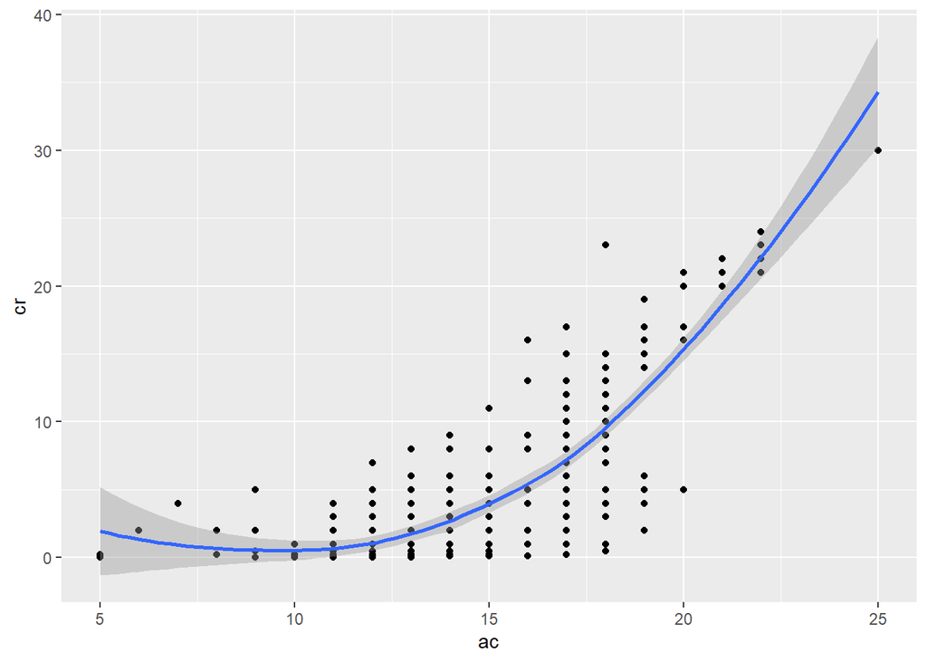

```r
DandData %>%
  select(ac, cr) %>%
  ggplot() +
  aes(x = ac, y = cr) +
  geom_point() +
  geom_smooth()
```

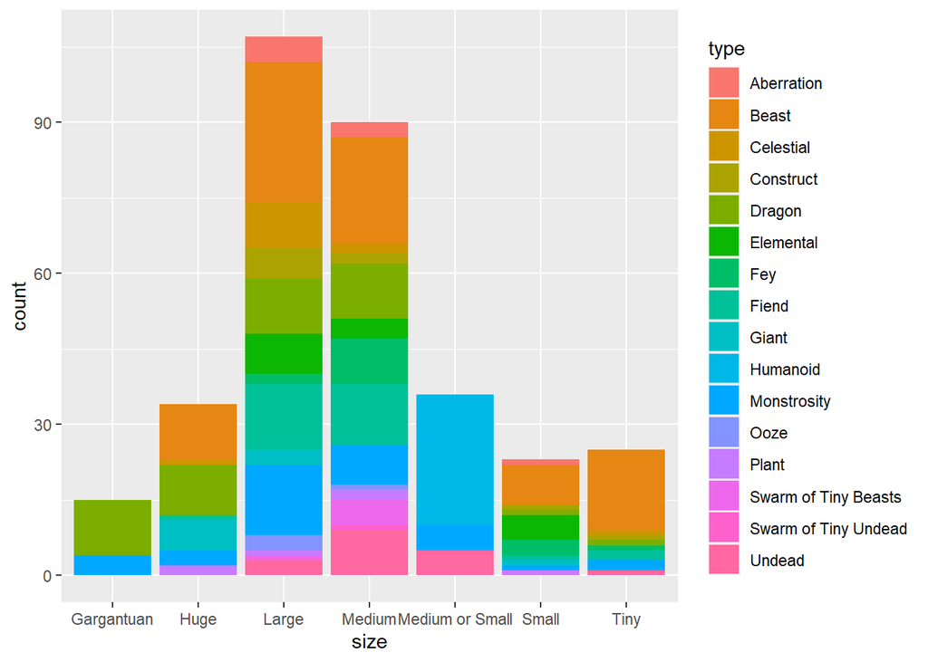

```r
DandData %>%
ggplot() +
aes(x = size, fill = type) +
geom_bar()
```

In the first graph we can see that there is a correlational tendency between armor class (ac) and crit rating (cr) however since there are just a few cases in the low ac, cr and the high counterparts they hacve a strong impact on the tendency.

We can see on the bar graph, that most creatures fall in the medium and large category. Beasts, monstrosities and dragons are almost represented in every category. The gargantuan category is dominated by dragons and no beasts can be found in the medium or small category.